Project 1 Ana Topasna

Before: Installing Packages

```r
#Installing Packages
library("tidyverse")
if (!require("tidytuesdayR", quietly = TRUE)) {
    install.packages("tidytuesdayR")
}

library("tidytuesdayR")
library("here")
```

```r
library("ggplot2")
```

Loading in the Data

```r
#Loading in the Data
if (!dir.exists(here("data"))) {
    dir.create(here("data"))
}

if (!file.exists(here("data", "chocolate.RDS"))) {
    url_csv <- "https://raw.githubusercontent.com/rfordatascience/tidytuesday/main/data/2022/2022-01-18/chocolate.csv"
    chocolate <- readr::read_csv(url_csv)

     saveRDS(chocolate, file = here("data", "chocolate.RDS"))
}

chocolate <- readRDS(here("data", "chocolate.RDS"))
as_tibble(chocolate)
```

```
## # A tibble: 2,530 × 10
##      ref company_manufacturer company_location review_date
##    <dbl> <chr>                <chr>                  <dbl>
##  1  2454 5150                 U.S.A.                  2019
##  2  2458 5150                 U.S.A.                  2019
##  3  2454 5150                 U.S.A.                  2019
##  4  2542 5150                 U.S.A.                  2021
##  5  2546 5150                 U.S.A.                  2021
##  6  2546 5150                 U.S.A.                  2021
##  7  2542 5150                 U.S.A.                  2021
##  8   797 A. Morin             France                  2012
##  9   797 A. Morin             France                  2012
## 10  1011 A. Morin             France                  2013
## # ℹ 2,520 more rows
## # ℹ 6 more variables: country_of_bean_origin <chr>,
## #   specific_bean_origin_or_bar_name <chr>, cocoa_percent <chr>,
## #   ingredients <chr>, most_memorable_characteristics <chr>, rating <dbl>
```

```r
glimpse(chocolate)
```

```
## Rows: 2,530
## Columns: 10
## $ ref                              <dbl> 2454, 2458, 2454, 2542, 2546, 2546, 2…
## $ company_manufacturer             <chr> "5150", "5150", "5150", "5150", "5150…
## $ company_location                 <chr> "U.S.A.", "U.S.A.", "U.S.A.", "U.S.A.…
## $ review_date                      <dbl> 2019, 2019, 2019, 2021, 2021, 2021, 2…
## $ country_of_bean_origin           <chr> "Tanzania", "Dominican Republic", "Ma…
## $ specific_bean_origin_or_bar_name <chr> "Kokoa Kamili, batch 1", "Zorzal, bat…
## $ cocoa_percent                    <chr> "76%", "76%", "76%", "68%", "72%", "8…
## $ ingredients                      <chr> "3- B,S,C", "3- B,S,C", "3- B,S,C", "…
## $ most_memorable_characteristics   <chr> "rich cocoa, fatty, bready", "cocoa, …
## $ rating                           <dbl> 3.25, 3.50, 3.75, 3.00, 3.00, 3.25, 3…
```

Part 1

Problem 1

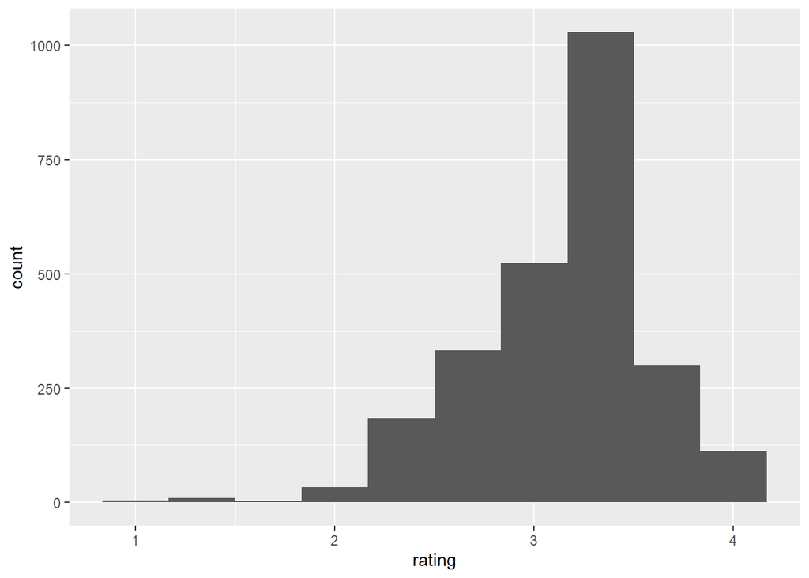

```r
#Make a histogram of the rating scores to visualize the overall distribution of scores. Change the number of bins from the default to 10, 15, 20, and 25. Pick on the one that you think looks the best. Explain what the difference is when you change the number of bins and explain why you picked the one you did.

p1 <- ggplot(data = chocolate, aes(x=rating))+
  geom_histogram(bins = 10)
p1
```

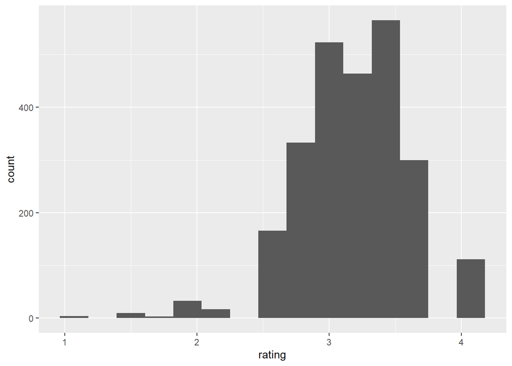

```r
p2 <- ggplot(data = chocolate, aes(x=rating))+
  geom_histogram(bins = 15)
p2
```

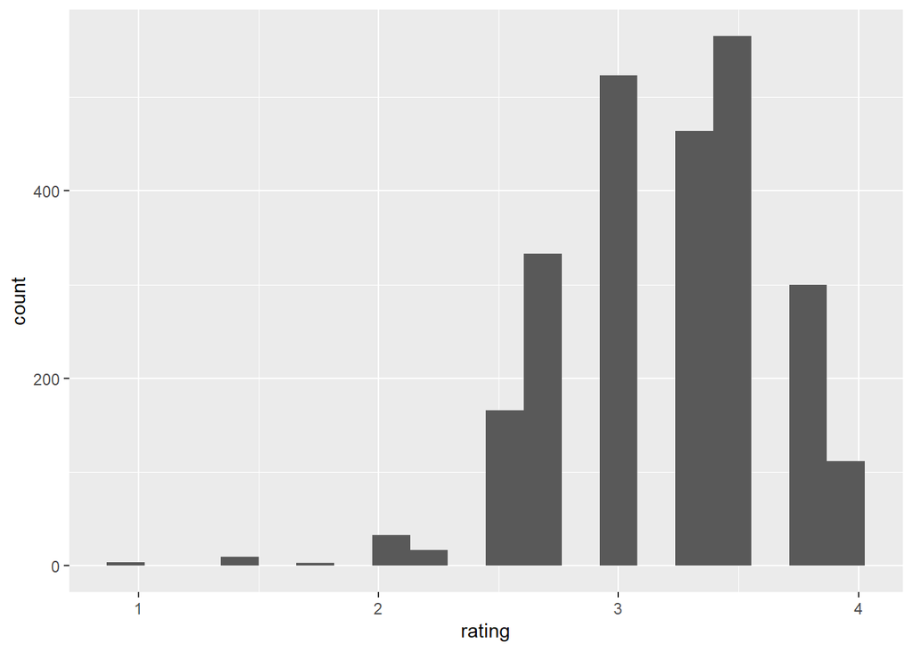

```r
p3 <- ggplot(data = chocolate, aes(x=rating))+
  geom_histogram(bins = 20)
p3
```

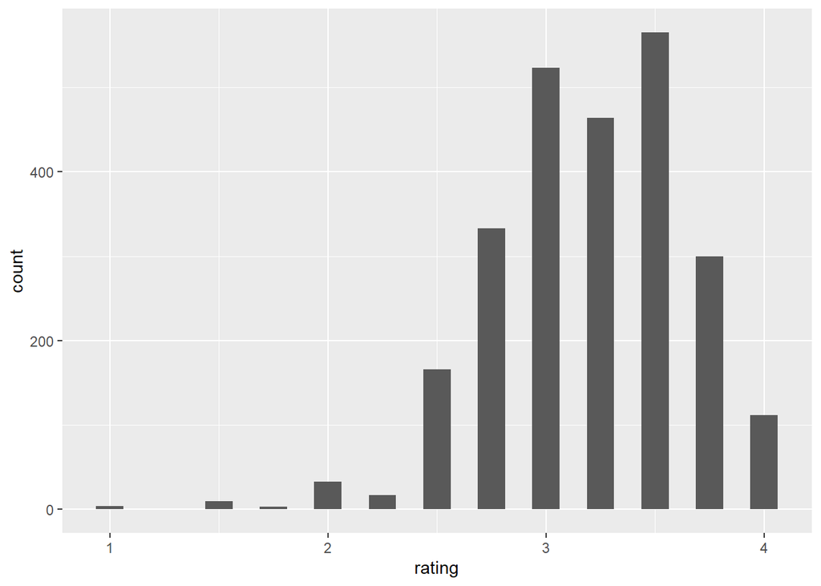

```r
p4 <- ggplot(data = chocolate, aes(x=rating))+
  geom_histogram(bins = 25)
p4
```

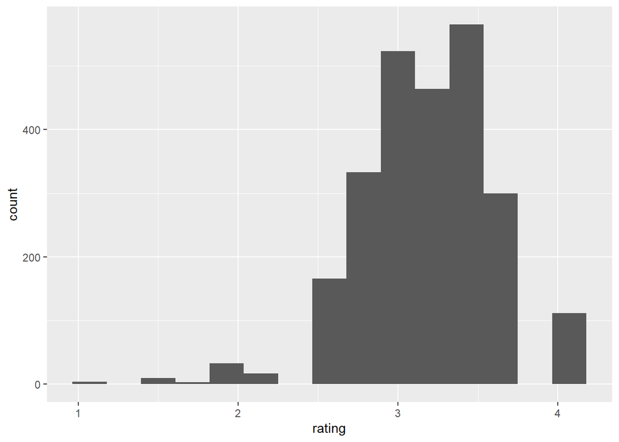

```r
#Best Graph:
p2
```

Problem 2

```r
#Consider the countries where the beans originated from. How many reviews come from each country of bean origin?

chocolate %>%
  count(country_of_bean_origin, name = "amounts")
```

```
## # A tibble: 62 × 2
##    country_of_bean_origin amounts
##    <chr>                    <int>
##  1 Australia                    3
##  2 Belize                      76
##  3 Blend                      156
##  4 Bolivia                     80
##  5 Brazil                      78
##  6 Burma                        1
##  7 Cameroon                     3
##  8 China                        1
##  9 Colombia                    79
## 10 Congo                       11
## # ℹ 52 more rows
```

Problem 3

```r
# Part 1: What is average rating scores from reviews of chocolate bars that have Ecuador as country_of_bean_origin in this dataset?

Only_Ecuador <- chocolate %>%
  filter(country_of_bean_origin == "Ecuador") %>%
  summarize(mean = mean(rating, na.rm = TRUE))

Only_Ecuador
```

```
## # A tibble: 1 × 1
##    mean
##   <dbl>
## 1  3.16
```

```r
# Part2: For this same set of reviews, also calculate (1) the total number of reviews

values_in_ecuador <- chocolate %>%
  filter(country_of_bean_origin == "Ecuador") %>%
  summarize(total =n())

values_in_ecuador
```

```
## # A tibble: 1 × 1
##   total
##   <int>
## 1   219
```

```r
#Note to self: summarize allows for non-unique values to be counted while count will look at unique values

#Part 3: (2) the standard deviation of the rating scores

sd_of_Ecuador <- chocolate %>%
  filter(country_of_bean_origin == "Ecuador") %>%
  summarize(sd = sd(rating, na.rm = TRUE))

sd_of_Ecuador
```

```
## # A tibble: 1 × 1
##      sd
##   <dbl>
## 1 0.512
```

```r
#Part 4: Your answer should be a new data frame with these three summary statistics in three columns. Label the name of these columns mean, sd, and total.

All_About_Ecuador <- tibble(Only_Ecuador, values_in_ecuador, sd_of_Ecuador)

All_About_Ecuador
```

```
## # A tibble: 1 × 3
##    mean total    sd
##   <dbl> <int> <dbl>
## 1  3.16   219 0.512
```

Problem 4

```r
#Which company location makes the best chocolate (or has the highest ratings on average) with beans from Ecuador?

Best_In_Ecuador <- chocolate %>%
  filter(country_of_bean_origin == "Ecuador") %>%
  group_by(company_location) %>%
  summarize(Mean_Location = mean(rating)) %>%
  arrange(desc(Mean_Location))

Best_In_Ecuador
```

```
## # A tibble: 25 × 2
##    company_location Mean_Location
##    <chr>                    <dbl>
##  1 Australia                 3.81
##  2 Switzerland               3.75
##  3 New Zealand               3.62
##  4 Hungary                   3.5
##  5 Israel                    3.5
##  6 Netherlands               3.5
##  7 Singapore                 3.5
##  8 South Korea               3.33
##  9 Canada                    3.28
## 10 U.S.A.                    3.26
## # ℹ 15 more rows
```

It looks like Australia makes the best chocolate with bean from Ecuador with an average of 3.8125.

Problem 5

```r
#Calculate the average rating across all country of origins for beans. Which top 3 countries (for bean origin) have the highest ratings on average?

Best_Beans_In_Show <- chocolate %>%
  group_by(country_of_bean_origin) %>%
  summarize(Avg_Bean_Rating = mean(rating)) %>%
  arrange(desc(Avg_Bean_Rating))

Best_Beans_In_Show
```

```
## # A tibble: 62 × 2
##    country_of_bean_origin Avg_Bean_Rating
##    <chr>                            <dbl>
##  1 Tobago                            3.62
##  2 China                             3.5
##  3 Sao Tome & Principe               3.5
##  4 Solomon Islands                   3.45
##  5 Congo                             3.32
##  6 Thailand                          3.3
##  7 Cuba                              3.29
##  8 Vietnam                           3.29
##  9 Papua New Guinea                  3.28
## 10 Madagascar                        3.27
## # ℹ 52 more rows
```

The top 3 countries are Tobago, China and Sao Tome and Principe.

Problem 6

```r
#Following up on the previous problem, now remove any countries of bean origins that have less than 10 chocolate bar reviews. Now, which top 3 countries have the highest ratings on average?

#Less_Than_Ten <- chocolate %>%
  #count(country_of_bean_origin, name = "amounts") %>%
  #filter(amounts > 10) %>%

More_Than_10_Reviews <- chocolate %>%
  group_by(country_of_bean_origin) %>%
  filter(n() >= 10)

#Note to self: this is s two step problem because if you try and use summarize on the data it will mutate it and change the rating column

Top_Reviews <- More_Than_10_Reviews %>%
  group_by(country_of_bean_origin) %>%
  summarize(Avg_Bean_Rating = mean(rating, na.rm = TRUE)) %>%
  arrange(desc(Avg_Bean_Rating))

Top_Reviews
```

```
## # A tibble: 35 × 2
##    country_of_bean_origin Avg_Bean_Rating
##    <chr>                            <dbl>
##  1 Solomon Islands                   3.45
##  2 Congo                             3.32
##  3 Cuba                              3.29
##  4 Vietnam                           3.29
##  5 Papua New Guinea                  3.28
##  6 Madagascar                        3.27
##  7 Haiti                             3.27
##  8 Brazil                            3.26
##  9 Guatemala                         3.26
## 10 Nicaragua                         3.26
## # ℹ 25 more rows
```

Solomon Islands, Cuba and Congo are the top countries when you remove the countries with less than 10 reviews.

Problem 7

```r
#Identify the countries of bean origin with at least 50 reviews. Remove reviews from countries are not in this list.
More_Than_50_Reviews <- chocolate %>%
  group_by(country_of_bean_origin) %>%
  filter(n() >= 50)

#Using the variable describing the chocolate percentage for each review, create a new column that groups chocolate percentages into one of four groups: (i) <60%, (ii) >=60 to <70%, (iii) >=70 to <90%, and (iii) >=90% (Hint check out the substr() function in base R and the case_when() function from dplyr – see example below).

Mutated_Chocolate <- More_Than_50_Reviews %>%
  mutate(Cocoa_Percentage_Groupings = case_when(
    cocoa_percent <= 60 ~ "<60%",
    cocoa_percent > 60 & cocoa_percent < 70 ~ ">=60 to <70",
    cocoa_percent >= 70 & cocoa_percent < 90 ~ ">=70 to <90",
    cocoa_percent >= 90 ~ ">=90"
  ))

#Mutated_Chocolate$Cocoa_Percentage_Groupings

#Using the new column described in #2, re-order the factor levels (if needed) to be starting with the smallest percentage group and increasing to the largest percentage group (Hint check out the fct_relevel() function from forcats).

Mutated_Chocolate$Cocoa_Percentage_Groupings <- fct_relevel(Mutated_Chocolate$Cocoa_Percentage_Groupings,"<60%", ">=60 to <70", ">=70 to <90", ">=90" )

levels(Mutated_Chocolate$Cocoa_Percentage_Groupings)
```

```
## [1] "<60%"        ">=60 to <70" ">=70 to <90" ">=90"
```

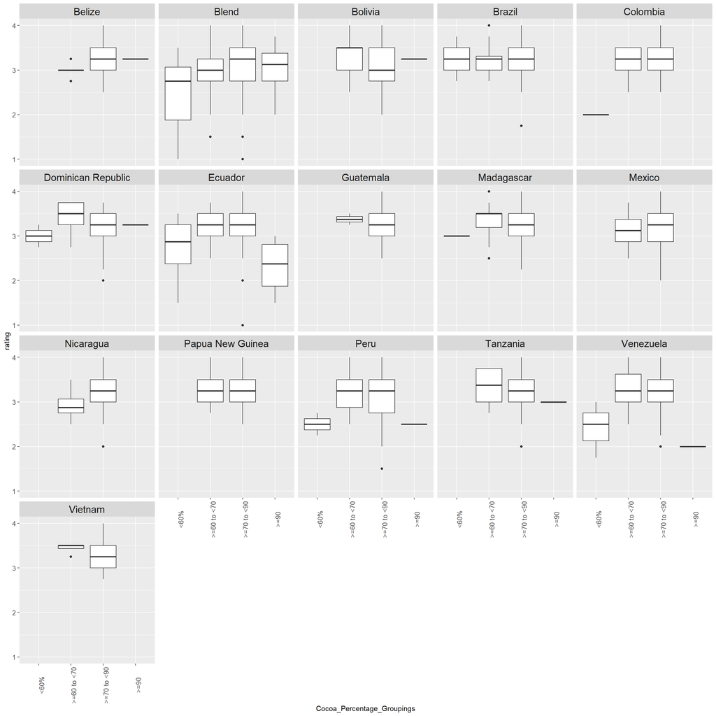

```r
#Note to self, you will not see the reordering in the actual data itself but when plotted in graphs it will plot in this order

#For each country, make a set of four side-by-side boxplots plotting the groups on the x-axis and the ratings on the y-axis. These plots should be faceted by country.


ggplot(Mutated_Chocolate, aes(x=Cocoa_Percentage_Groupings, y = rating)) +
  geom_boxplot(width = 0.8)+
  facet_wrap(~ country_of_bean_origin, ncol = 5) +
  theme(axis.text.x = element_text(size = 10, angle = 90, vjust = 1), axis.text.y = element_text(size =10), strip.text = element_text(size =15))
```

On average, which category of chocolate percentage is most highly rated? Do these countries mostly agree or are there disagreements? -> It seems that the two middle categories of chocolate are the most highly rated. I would say that most countries agree however there is missing data from several countries, such that they only have two categories of chocolate percentage. The addition of more data may change this.

Part 2

```r
#Use this dataset it to create a new column called continent in our chocolate dataset1 that contains the continent name for each review where the country of bean origin is.
library(gapminder)

Renamed_Chocolate <- chocolate %>%
  rename(country = country_of_bean_origin)

gapminder_clean <- gapminder %>%
  select(country, continent) %>%
  distinct() #this is something i need to go over

Cont_Added <- left_join(Renamed_Chocolate, select(gapminder_clean, country, continent), by = "country")

Cont_Added
```

```
## # A tibble: 2,530 × 11
##      ref company_manufacturer company_location review_date country
##    <dbl> <chr>                <chr>                  <dbl> <chr>
##  1  2454 5150                 U.S.A.                  2019 Tanzania
##  2  2458 5150                 U.S.A.                  2019 Dominican Republic
##  3  2454 5150                 U.S.A.                  2019 Madagascar
##  4  2542 5150                 U.S.A.                  2021 Fiji
##  5  2546 5150                 U.S.A.                  2021 Venezuela
##  6  2546 5150                 U.S.A.                  2021 Uganda
##  7  2542 5150                 U.S.A.                  2021 India
##  8   797 A. Morin             France                  2012 Bolivia
##  9   797 A. Morin             France                  2012 Peru
## 10  1011 A. Morin             France                  2013 Panama
## # ℹ 2,520 more rows
## # ℹ 6 more variables: specific_bean_origin_or_bar_name <chr>,
## #   cocoa_percent <chr>, ingredients <chr>,
## #   most_memorable_characteristics <chr>, rating <dbl>, continent <fct>
```

```r
#Only keep reviews that have reviews from countries of bean origin with at least 10 reviews.

More_Than_10_Reviews_Again <- Cont_Added %>%
  group_by(country) %>%
  filter(n() >= 10) ####

More_Than_10_Reviews_Again
```

```
## # A tibble: 2,448 × 11
## # Groups:   country [35]
##      ref company_manufacturer company_location review_date country
##    <dbl> <chr>                <chr>                  <dbl> <chr>
##  1  2454 5150                 U.S.A.                  2019 Tanzania
##  2  2458 5150                 U.S.A.                  2019 Dominican Republic
##  3  2454 5150                 U.S.A.                  2019 Madagascar
##  4  2542 5150                 U.S.A.                  2021 Fiji
##  5  2546 5150                 U.S.A.                  2021 Venezuela
##  6  2546 5150                 U.S.A.                  2021 Uganda
##  7  2542 5150                 U.S.A.                  2021 India
##  8   797 A. Morin             France                  2012 Bolivia
##  9   797 A. Morin             France                  2012 Peru
## 10  1015 A. Morin             France                  2013 Colombia
## # ℹ 2,438 more rows
## # ℹ 6 more variables: specific_bean_origin_or_bar_name <chr>,
## #   cocoa_percent <chr>, ingredients <chr>,
## #   most_memorable_characteristics <chr>, rating <dbl>, continent <fct>
```

```r
#Also, remove the country of bean origin named "Blend".

No_Blend <- More_Than_10_Reviews_Again %>%
  filter(country != "Blend")

nrow(More_Than_10_Reviews_Again)
```

```
## [1] 2448
```

```r
nrow(No_Blend)
```

```
## [1] 2292
```

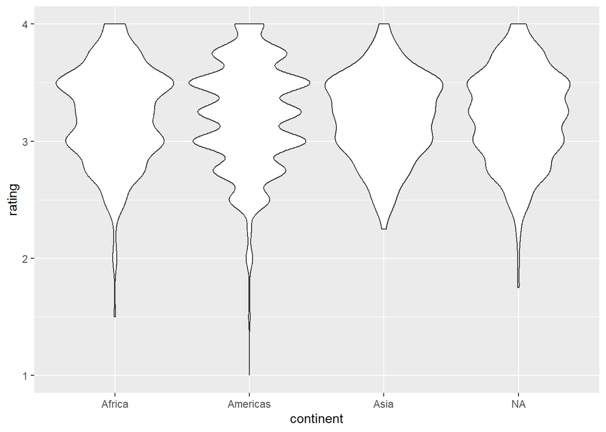

```r
#Worked
#Make a set of violin plots with ratings on the y-axis and continents on the x-axis.

Violin_Ch <- ggplot(No_Blend, aes(x=continent, y = rating)) +
  geom_violin()

Violin_Ch
```

```r
NA_Values <- No_Blend %>%
  filter(is.na(continent))

NA_Values
```

```
## # A tibble: 294 × 11
## # Groups:   country [11]
##      ref company_manufacturer          company_location review_date country
##    <dbl> <chr>                         <chr>                  <dbl> <chr>
##  1  2542 5150                          U.S.A.                  2021 Fiji
##  2  1015 A. Morin                      France                  2013 Papua New G…
##  3  1876 A. Morin                      France                  2016 Sao Tome
##  4   705 Adi aka Fijiana (Easy In Ltd) Fiji                    2011 Fiji
##  5   705 Adi aka Fijiana (Easy In Ltd) Fiji                    2011 Fiji
##  6   705 Adi aka Fijiana (Easy In Ltd) Fiji                    2011 Fiji
##  7   705 Adi aka Fijiana (Easy In Ltd) Fiji                    2011 Fiji
##  8  2438 Aelan                         Vanuatu                 2019 Vanuatu
##  9  2438 Aelan                         Vanuatu                 2019 Vanuatu
## 10  2442 Aelan                         Vanuatu                 2019 Vanuatu
## # ℹ 284 more rows
## # ℹ 6 more variables: specific_bean_origin_or_bar_name <chr>,
## #   cocoa_percent <chr>, ingredients <chr>,
## #   most_memorable_characteristics <chr>, rating <dbl>, continent <fct>
```

```r
NA_Values %>%
  group_by(country) %>%
  summarize(n=n()) #11 Counties that need to be changed
```

```
## # A tibble: 11 × 2
##    country              n
##    <chr>            <int>
##  1 Belize              76
##  2 Congo               11
##  3 Fiji                16
##  4 Grenada             19
##  5 Papua New Guinea    50
##  6 Sao Tome            14
##  7 Solomon Islands     10
##  8 St. Lucia           10
##  9 Trinidad            42
## 10 U.S.A.              33
## 11 Vanuatu             13
```

```r
Fixed_noblend <- No_Blend %>%
  mutate(continent = case_when(
    country == "Belize" ~ "Americas",
    country == "Congo" ~  "Africa",
    country == "Fiji" ~ "Oceania",
    country == "Grenada" ~ "Americas",
    country == "Papua New Guinea" ~ "Oceania",
    country == "Sao Tome" ~ "Africa",
    country == "Trinidad" ~"Americas",
    country == "U.S.A." ~ "Americas",
    country == "Vanuatu" ~ "Oceania",
    country == "Solomon Islands" ~ "Oceania",
    country == "St. Lucia" ~ "Americas",
    TRUE ~ continent
  ))
#note to self: you have to add true at the end because if not it will mutate everything else that is not part of the above command to be NA

test_na <- Fixed_noblend %>%
  filter(is.na(continent))

test_na
```

```
## # A tibble: 0 × 11
## # Groups:   country [0]
## # ℹ 11 variables: ref <dbl>, company_manufacturer <chr>,
## #   company_location <chr>, review_date <dbl>, country <chr>,
## #   specific_bean_origin_or_bar_name <chr>, cocoa_percent <chr>,
## #   ingredients <chr>, most_memorable_characteristics <chr>, rating <dbl>,
## #   continent <chr>
```

```r
test_na %>%
  group_by(country) %>%
  summarize(n=n())
```

```
## # A tibble: 0 × 2
## # ℹ 2 variables: country <chr>, n <int>
```

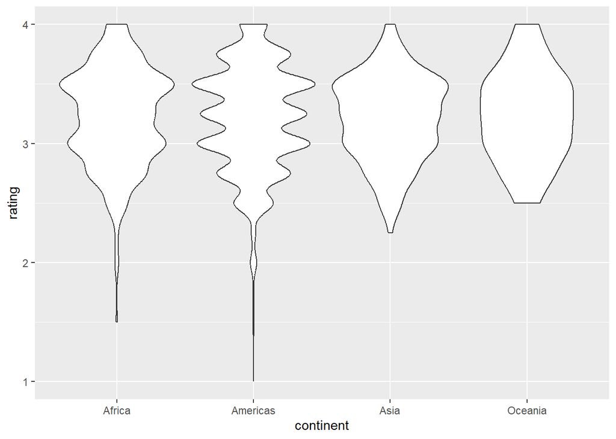

```r
Violin_Ch_2 <- ggplot(Fixed_noblend, aes(x=continent, y = rating)) +
  geom_violin()

Violin_Ch_2
```

```r
Fixed_noblend
```

```
## # A tibble: 2,292 × 11
## # Groups:   country [34]
##      ref company_manufacturer company_location review_date country
##    <dbl> <chr>                <chr>                  <dbl> <chr>
##  1  2454 5150                 U.S.A.                  2019 Tanzania
##  2  2458 5150                 U.S.A.                  2019 Dominican Republic
##  3  2454 5150                 U.S.A.                  2019 Madagascar
##  4  2542 5150                 U.S.A.                  2021 Fiji
##  5  2546 5150                 U.S.A.                  2021 Venezuela
##  6  2546 5150                 U.S.A.                  2021 Uganda
##  7  2542 5150                 U.S.A.                  2021 India
##  8   797 A. Morin             France                  2012 Bolivia
##  9   797 A. Morin             France                  2012 Peru
## 10  1015 A. Morin             France                  2013 Colombia
## # ℹ 2,282 more rows
## # ℹ 6 more variables: specific_bean_origin_or_bar_name <chr>,
## #   cocoa_percent <chr>, ingredients <chr>,
## #   most_memorable_characteristics <chr>, rating <dbl>, continent <chr>
```

Part 3

```r
#Create a new set of columns titled beans, sugar, cocoa_butter, vanilla, letchin, and salt that contain a 1 or 0 representing whether or not that review for the chocolate bar contained that ingredient (1) or not (0).
#beans
c_copy <- chocolate
c_copy$beans <- as.numeric (str_detect(chocolate$ingredients, "B"))

c_copy$cocoa_butter <- as.numeric (str_detect(chocolate$ingredients, "C"))

c_copy$vanilla <- as.numeric (str_detect(chocolate$ingredients, "V"))

c_copy$letchin <- as.numeric (str_detect(chocolate$ingredients, "L"))

c_copy$sugar <- as.numeric (str_detect(chocolate$ingredients, "S"))

c_copy$salt <- as.numeric (str_detect(chocolate$ingredients, "Sa"))
c_copy
```

```
## # A tibble: 2,530 × 16
##      ref company_manufacturer company_location review_date
##    <dbl> <chr>                <chr>                  <dbl>
##  1  2454 5150                 U.S.A.                  2019
##  2  2458 5150                 U.S.A.                  2019
##  3  2454 5150                 U.S.A.                  2019
##  4  2542 5150                 U.S.A.                  2021
##  5  2546 5150                 U.S.A.                  2021
##  6  2546 5150                 U.S.A.                  2021
##  7  2542 5150                 U.S.A.                  2021
##  8   797 A. Morin             France                  2012
##  9   797 A. Morin             France                  2012
## 10  1011 A. Morin             France                  2013
## # ℹ 2,520 more rows
## # ℹ 12 more variables: country_of_bean_origin <chr>,
## #   specific_bean_origin_or_bar_name <chr>, cocoa_percent <chr>,
## #   ingredients <chr>, most_memorable_characteristics <chr>, rating <dbl>,
## #   beans <dbl>, cocoa_butter <dbl>, vanilla <dbl>, letchin <dbl>, sugar <dbl>,
## #   salt <dbl>
```

```r
#Create a new set of columns titled char_cocoa, char_sweet, char_nutty, char_creamy, char_roasty, char_earthy that contain a 1 or 0 representing whether or not that the most memorable characteristic for the chocolate bar had that word (1) or not (0). For example, if the word “sweet” appears in the most_memorable_characteristics, then record a 1, otherwise a 0 for that review in the char_sweet column

c_copy$char_sweet <- as.numeric (str_detect(chocolate$most_memorable_characteristics, "sweet"))

c_copy$char_cocoa <- as.numeric (str_detect(chocolate$most_memorable_characteristics, "cocoa"))

c_copy$char_nutty <- as.numeric (str_detect(chocolate$most_memorable_characteristics, "nutty"))

c_copy$char_creamy <- as.numeric (str_detect(chocolate$most_memorable_characteristics, "creamy"))

c_copy$char_roasty <- as.numeric (str_detect(chocolate$most_memorable_characteristics, "roasty"))

c_copy$char_earthy <- as.numeric (str_detect(chocolate$most_memorable_characteristics, "earthy"))
c_copy
```

```
## # A tibble: 2,530 × 22
##      ref company_manufacturer company_location review_date
##    <dbl> <chr>                <chr>                  <dbl>
##  1  2454 5150                 U.S.A.                  2019
##  2  2458 5150                 U.S.A.                  2019
##  3  2454 5150                 U.S.A.                  2019
##  4  2542 5150                 U.S.A.                  2021
##  5  2546 5150                 U.S.A.                  2021
##  6  2546 5150                 U.S.A.                  2021
##  7  2542 5150                 U.S.A.                  2021
##  8   797 A. Morin             France                  2012
##  9   797 A. Morin             France                  2012
## 10  1011 A. Morin             France                  2013
## # ℹ 2,520 more rows
## # ℹ 18 more variables: country_of_bean_origin <chr>,
## #   specific_bean_origin_or_bar_name <chr>, cocoa_percent <chr>,
## #   ingredients <chr>, most_memorable_characteristics <chr>, rating <dbl>,
## #   beans <dbl>, cocoa_butter <dbl>, vanilla <dbl>, letchin <dbl>, sugar <dbl>,
## #   salt <dbl>, char_sweet <dbl>, char_cocoa <dbl>, char_nutty <dbl>,
## #   char_creamy <dbl>, char_roasty <dbl>, char_earthy <dbl>
```

```r
#For each year (i.e. review_date), calculate the mean value in each new column you created across all reviews for that year. (Hint: If all has gone well thus far, you should have a dataset with 16 rows and 13 columns).

avg_by_year <- c_copy %>%
  group_by(review_date) %>%
  summarize(beans_mean = mean(beans, na.rm =TRUE),
            sugar_mean = mean(sugar, na.rm =TRUE),
            cocoa_butter_mean = mean(cocoa_butter, na.rm =TRUE),
            vanilla_mean = mean(vanilla, na.rm =TRUE),
            letchin_mean = mean(letchin, na.rm =TRUE),
            salt_mean = mean(salt, na.rm =TRUE),
            char_cocoa_mean = mean(char_cocoa, na.rm =TRUE),
            char_sweet_mean = mean(char_sweet, na.rm =TRUE),
            char_nutty_mean = mean(char_nutty, na.rm =TRUE),
            char_creamy_mean = mean(char_creamy, na.rm =TRUE),
            char_roasty_mean = mean(char_roasty, na.rm =TRUE),
            char_earthy_mean = mean(char_earthy, na.rm =TRUE))

avg_by_year
```

```
## # A tibble: 16 × 13
##    review_date beans_mean sugar_mean cocoa_butter_mean vanilla_mean letchin_mean
##          <dbl>      <dbl>      <dbl>             <dbl>        <dbl>        <dbl>
##  1        2006          1      1                 0.933       0.717        0.717
##  2        2007          1      1                 0.812       0.580        0.406
##  3        2008          1      0.988             0.821       0.393        0.560
##  4        2009          1      1                 0.841       0.354        0.372
##  5        2010          1      1                 0.830       0.266        0.457
##  6        2011          1      1                 0.739       0.170        0.170
##  7        2012          1      1                 0.728       0.2          0.133
##  8        2013          1      0.989             0.802       0.215        0.305
##  9        2014          1      1                 0.654       0.0700       0.123
## 10        2015          1      0.993             0.554       0.0607       0.121
## 11        2016          1      0.995             0.606       0.0516       0.108
## 12        2017          1      1                 0.573       0.0291       0.136
## 13        2018          1      1                 0.604       0.0622       0.133
## 14        2019          1      1                 0.679       0.0259       0.202
## 15        2020          1      1                 0.568       0.0370       0.0247
## 16        2021          1      0.994             0.646       0.0114       0.08
## # ℹ 7 more variables: salt_mean <dbl>, char_cocoa_mean <dbl>,
## #   char_sweet_mean <dbl>, char_nutty_mean <dbl>, char_creamy_mean <dbl>,
## #   char_roasty_mean <dbl>, char_earthy_mean <dbl>
```

```r
#Convert this wide dataset into a long dataset with a new feature and mean_score column.
long_chocolate <-avg_by_year %>%
  pivot_longer(-review_date, names_to = "feature", values_to = "mean_score")

long_chocolate
```

```
## # A tibble: 192 × 3
##    review_date feature           mean_score
##          <dbl> <chr>                  <dbl>
##  1        2006 beans_mean            1
##  2        2006 sugar_mean            1
##  3        2006 cocoa_butter_mean     0.933
##  4        2006 vanilla_mean          0.717
##  5        2006 letchin_mean          0.717
##  6        2006 salt_mean             0
##  7        2006 char_cocoa_mean       0.210
##  8        2006 char_sweet_mean       0.161
##  9        2006 char_nutty_mean       0.0323
## 10        2006 char_creamy_mean      0.242
## # ℹ 182 more rows
```

Part 4

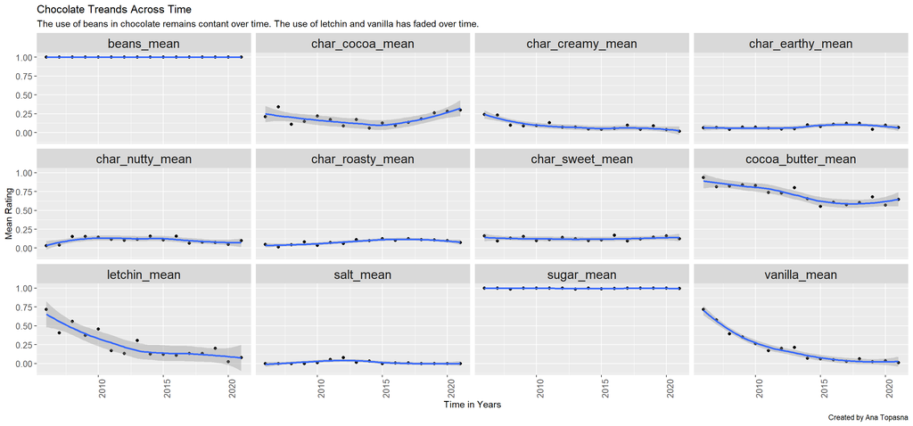

```r
#Use the functions in ggplot2 package to make a scatter plot of the mean_scores (y-axis) over time (x-axis). There should be one plot (facet) for each feature. For full credit, your plot should include:An overall title for the plot and a subtitle summarizing key trends that you found. Also include a caption in the figure with your name.Both the observed points for the mean_score, but also a smoothed non-linear pattern of the trendAll plots should be shown in the one figureThere should be an informative x-axis and y-axis label

scatter_c <- ggplot(data = long_chocolate, aes(x = review_date, y = mean_score))+
  geom_point()+
  facet_wrap(~feature)+
  theme(axis.text.x = element_text(size = 10, angle = 90, vjust = 1), axis.text.y = element_text(size =10), strip.text = element_text(size =15))+
  labs(title = "Chocolate Treands Across Time", subtitle = "The use of beans in chocolate remains contant over time. The use of letchin and vanilla has faded over time.", caption = "Created by Ana Topasna", x = "Time in Years", y = "Mean Rating")+
  geom_smooth()

scatter_c
```

```r
#go back and look at theme, se = false
#look into y axis
```

Part 5

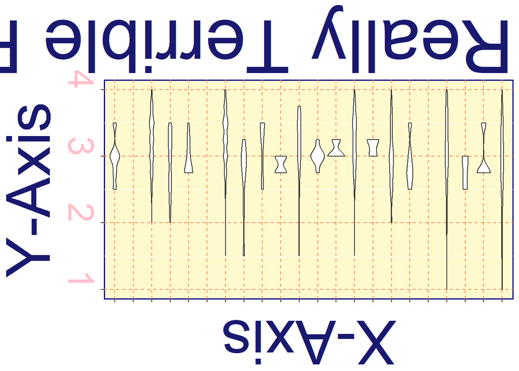

```r
#Make the absolute worst plot that you can. You need to customize it in at least 7 ways to make it awful.

#In your document, write 1 - 2 sentences about each different customization you added (using bullets – i.e. there should be at least 7 bullet points each with 1-2 sentences), and how it could be useful for you when you want to make an awesome data visualization.

bad_plot <- ggplot(data = chocolate, aes(x= ingredients, y= rating))+
  geom_violin()+
  theme(axis.text.x = element_text(size=0.0004, color = "greenyellow"), axis.text.y = element_text(size=35, angle = -90, color = "pink"), title = element_text(angle = -180, size = 59, color = "midnightblue"), panel.background = element_rect(fill = "lemonchiffon", color = "darkblue", size = 1), panel.grid.major = element_line(color = "coral", linetype = "dashed"))+
  labs(title = "Really Terrible Plot", x = "X-Axis", y = "Y-Axis")
bad_plot
```

-For this plot I chose to plot ingredients and ratings in a violin plot. I chose to use the original ingredients column as the X and now the binary version that we created, making it hard to read and interpret. For a more useful graph I should have done something like the one we made for part 4 where the individual features are faceted. -I made the X axis incredibly tiny. This makes it virtually unreadable so you don’t know what you’re looking at and forces the reader to find this information elsewhere. -I made the color for the x-axis a neon color that is unreadable so that even if the text was visible it would hurt the reader to look at it. -I made the Y-axis incredibly large such that it looks strange and makes the graph hard to read. This forces the reader to look at this graph for much longer. -I flipped the Y-axis text upside down so that it becomes even more difficult to read.In a good graph it may be useful to have the text at a angle but fully upside down doesn’t work. -I made the Y-axis a strange pink color that is different from the colors of the rest of the text of the graph. In a better graph I would try and keep the color of all of the text more consistent. -The title of the graph is so big it wraps around the graph and compresses it making it hard to read such a small graph.In a better graph it would be big but not so big it is a problem. -The title is upside down and a different color than the rest of the graph so that you have no idea what your’e looking at when you look at an already badly made and tiny graph. -The actual color of the graph is a mix of 3 colors that are not color-blind friendly. For a future better graph I would want to use one of the pre-set color palettes in R that are color blind friendly. -The x and Y axis are not labled in a helpful manner and neither is the title so that even if things were not upside down you would not be able to understand what you are looking at. A future better graph would have a more helpful set of axis.

Part 6

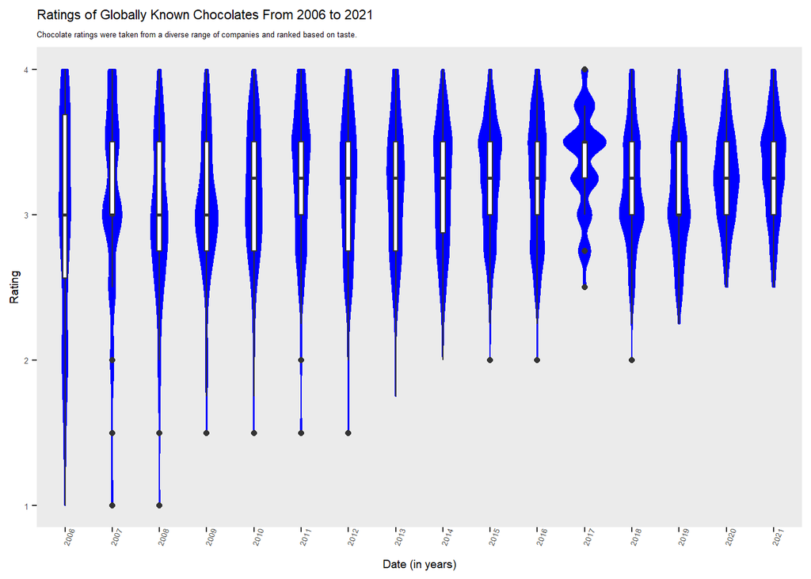

```r
#You need to customize it in at least 7 ways to make it better. In your document, write 1 - 2 sentences about each different customization you added (using bullets – i.e. there should be at least 7 bullet points each with 1-2 sentences), describing how you improved it.

improved_plot <- chocolate %>%
    ggplot(aes(
        x = as.factor(review_date),
        y = rating,
    )) +
    geom_violin(color = "blue", fill = "blue")+
  labs(title = "Ratings of Globally Known Chocolates From 2006 to 2021", x = "Date (in years)", y ="Rating", subtitle = "Chocolate ratings were taken from a diverse range of companies and ranked based on taste.")+
  theme(axis.text.x = element_text(size=5, angle = 70), axis.text.y = element_text(size=5), title = element_text(size = 7), panel.grid.major = element_blank(), panel.grid.minor = element_blank(), plot.subtitle = element_text(size = 5))+
   geom_boxplot(width = 0.1)

improved_plot #change the last thing to be a summary statistic, geom_smooth would be good to add here, geom_smooth(method = "lm"),  geom_violin(draw_quantiles = c(0.25, 0.5, 0.75))
```

```r
options(width = 120)
```